# Lab notebook - Dec 2021-May 2022

# 2022-01-11

## Hox genes: new cultivation with hoxA and hoxH

- previous hoxA cultivations in MC did not show promising µ increase as shown in plate reader pre-experiments
- maybe precultures were not viable or contaminated; to finalize hoxA analysis, cultivation is redone with 4 replicates
- prepared precultures 3x 5 mL flask with MM + 2 g/L Frc and 1 g/L NH4Cl
- inoculated: delta hoxA, hoxH, hoxG (did not grow, plate old)

# 2022-01-13

## Hox genes: new cultivation with hoxA and hoxH

- hoxA and hoxH precultures have grown
- prepared MC2 batch cultivation as before, without WT
- setup: 4x hoxA, 4x hoxH, alternating order in MC (A, H, A, H, …)

# 2022-01-17

## Hox genes: new cultivation with hoxA and hoxH

- cultivation finished without problems
- hoxA slightly higher growth rate then hoxH, especially at the beginning of the cultivation
- Results below:

```r
df_OD_20220114 <- read_csv(paste0(dir_exp, "20220114_MC2_batch_mutants/20220114_MC2_measurements.csv"),
  show_col_types = FALSE, col_select = -1) %>% filter(od_led == 720) %>%
  mutate(sample = case_when(channel_id %in% c(1,3,5,7) ~ "hoxA", channel_id %in% c(2,4,6,8) ~ "hoxH")) %>%
  group_by(sample, batchtime_h) %>% mutate(replicate = 1:n())
df_mu_20220114 <- read_csv(paste0(dir_exp, "20220114_MC2_batch_mutants/MU.csv"),
  show_col_types = FALSE, col_select = -1) %>%
  filter(batchtime_h > 5) %>%
  mutate(sample = case_when(channel_id %in% c(1,3,5,7) ~ "hoxA", channel_id %in% c(2,4,6,8) ~ "hoxH")) %>%
  group_by(sample, batchtime_h) %>% mutate(replicate = 1:n())
```

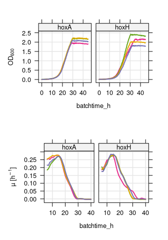

```r
print(plot_OD(df_OD_20220114, groups = "replicate", layout = c(2,1)), split = c(1,1,1,2), more = TRUE)
print(plot_MU(df_mu_20220114, groups = "replicate", layout = c(2,1)), split = c(1,2,1,2), more = TRUE)
```

**Final DCW and biomass yield of 2nd batch cultivation**

```r
df_DCW_20220114 <- data.frame(
    sample = rep(c("hoxA", "hoxH"), each = 4),
    tube_weight_mg = c(990.10, 1000.97, 997.56, 1004.62, 1001.22, 991.26, 991.15, 996.61),
    total_weight_mg = c(1039.45, 1050.52, 1044.78, 1055.96, 1045.28, 1037.70, 1041.15, 1046.80)
  ) %>%
  mutate(
    DCW_mg = total_weight_mg - tube_weight_mg,
    yield_gDCW_gFRC = DCW_mg/(1000 * 2.0 * 0.05)
  )

df_DCW_20220114
```

| sample | tube_weight_mg | total_weight_mg | DCW_mg | yield_gDCW_gFRC |
| --- | --- | --- | --- | --- |
| hoxA | 990.10 | 1039.45 | 49.35 | 0.4935 |
| hoxA | 1000.97 | 1050.52 | 49.55 | 0.4955 |
| hoxA | 997.56 | 1044.78 | 47.22 | 0.4722 |
| hoxA | 1004.62 | 1055.96 | 51.34 | 0.5134 |
| hoxH | 1001.22 | 1045.28 | 44.06 | 0.4406 |
| hoxH | 991.26 | 1037.70 | 46.44 | 0.4644 |
| hoxH | 991.15 | 1041.15 | 50.00 | 0.5000 |
| hoxH | 996.61 | 1046.80 | 50.19 | 0.5019 |

**Comparison of maximum growth rate and yield**

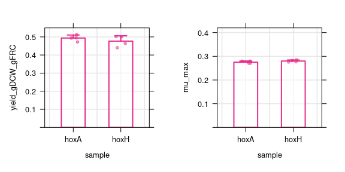

```r
plot_barchart(df_DCW_20220114, "sample", "yield_gDCW_gFRC", ylim = c(0, 0.55), offset = 0.1) %>%
  print(position = c(0,0,0.5,1), more = TRUE)

df_mu_20220114 %>% filter(batchtime_h > 5) %>%
  group_by(sample, channel_id) %>% summarize(mu_max = max(value), .groups = "drop") %>%
  arrange(channel_id) %>%
  plot_barchart("sample", "mu_max", ylim = c(0, 0.42), offset = 0.07) %>%
  print(position = c(0.5,0,1,1))
```

# 2022-03-25

## Cultivation of hox/hyp mutants in chemostat fructose, then formate

**preparations for further cultivations**

- plated all mutants on LB, from -80 cryostocks
- inoculated 5 mL MM + Frc precultures
- prepared bioreactor tubes, 8x chemostat setup + 8x batch setup
- prepared medium 2x 2L R.e. MM

**long term goals**

- cultivate remaining mutant hoxG in fructose, batch
- obtain yield (and max growth rate?) in chemostat or turbidostat for all hox/hyp mutants

# 2022-03-31

## Cultivation of hoxG in batch (last remaining mutant)

- preparation of 3 additional precultures (2022-03-28), hoxG, WT in MM, hoxA in LB to make fresh cryo stock
- start batch bioreactor with hoxG + WT
- MC3 with 50 mL MM +2 g/L Frc, 1 g/L NH4Cl
- low starting OD600 = 0.005, as before
- 100 mL/min aeration
- start: 16:00

```r
tibble(
    strain = c("WT", "hoxG"),
    OD600_diluted = c(0.482, 0.515)
  ) %>%
  mutate(
    OD600 = OD600_diluted*4,
    V_for_OD_0.005 = 0.005/OD600,
    V_for_50_mL = V_for_OD_0.005*50
  )
```

| strain | OD600_diluted | OD600 | V_for_OD_0.005 | V_for_50_mL |
| --- | --- | --- | --- | --- |
| WT | 0.482 | 1.928 | 0.002593361 | 0.1296680 |
| hoxG | 0.515 | 2.060 | 0.002427184 | 0.1213592 |

# 2022-04-04

## Cultivation of hoxG in batch (last remaining mutant)

- cultivation finished without problems
- Results:

```r
df_OD_20220404 <- read_csv(paste0(dir_exp, "20220331_MC3_batch_mutants/20220331_MC3_measurements.csv"),
  show_col_types = FALSE, col_select = -1) %>% filter(od_led == 720) %>%
  mutate(sample = case_when(channel_id %in% c(1,3,5,7) ~ "WT", channel_id %in% c(2,4,6,8) ~ "hoxG")) %>%
  group_by(sample, batchtime_h) %>% mutate(replicate = 1:n())
df_mu_20220404 <- read_csv(paste0(dir_exp, "20220331_MC3_batch_mutants/MU.csv"),
  show_col_types = FALSE, col_select = -1) %>%
  filter(batchtime_h > 5) %>%
  mutate(value = case_when(channel_id == 3 & batchtime_h < 12 ~ NaN, TRUE ~ value)) %>%
  mutate(sample = case_when(channel_id %in% c(1,3,5,7) ~ "WT", channel_id %in% c(2,4,6,8) ~ "hoxG")) %>%
  group_by(sample, batchtime_h) %>% mutate(replicate = 1:n())
```

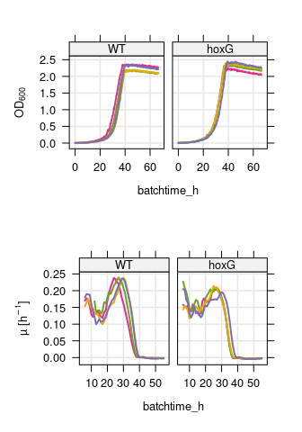

```r
print(plot_OD(df_OD_20220404, groups = "replicate", layout = c(2,1)), split = c(1,1,1,2), more = TRUE)
print(plot_MU(df_mu_20220404, groups = "replicate", layout = c(2,1)), split = c(1,2,1,2), more = TRUE)
```

**Final DCW and biomass yield**

```r
df_DCW_20220404 <- data.frame(
    sample = rep(c("WT", "hoxG"), each = 4),
    tube_weight_mg = c(1000.8, 1004.8, 1006.7, 1013.1, 1000.9, 1012.6, 1024.8, 1000.4),
    total_weight_mg = c(1036.7, 1041.0, 1043.2, 1049.1, 1036.4, 1048.4, 1060.7, 1036.0)
  ) %>%
  mutate(
    DCW_mg = total_weight_mg - tube_weight_mg,
    yield_gDCW_gFRC = DCW_mg/(1000 * 2.0 * 0.05)
  )

df_DCW_20220404
```

| sample | tube_weight_mg | total_weight_mg | DCW_mg | yield_gDCW_gFRC |
| --- | --- | --- | --- | --- |
| WT | 1000.8 | 1036.7 | 35.9 | 0.359 |
| WT | 1004.8 | 1041.0 | 36.2 | 0.362 |
| WT | 1006.7 | 1043.2 | 36.5 | 0.365 |
| WT | 1013.1 | 1049.1 | 36.0 | 0.360 |
| hoxG | 1000.9 | 1036.4 | 35.5 | 0.355 |
| hoxG | 1012.6 | 1048.4 | 35.8 | 0.358 |
| hoxG | 1024.8 | 1060.7 | 35.9 | 0.359 |
| hoxG | 1000.4 | 1036.0 | 35.6 | 0.356 |

**Comparison of maximum growth rate and yield**

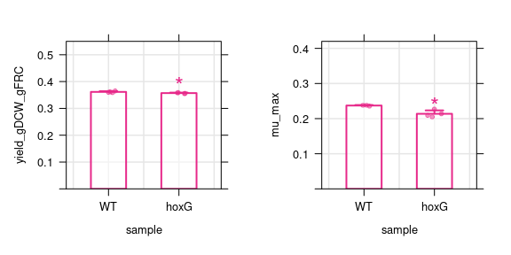

```r
plot_barchart(df_DCW_20220404, "sample", "yield_gDCW_gFRC", ylim = c(0, 0.55), offset = 0.1) %>%
  print(position = c(0,0,0.5,1), more = TRUE)

df_mu_20220404 %>% filter(batchtime_h > 5) %>%
  group_by(sample, channel_id) %>% summarize(mu_max = max(value), .groups = "drop") %>%
  arrange(channel_id) %>%
  plot_barchart("sample", "mu_max", ylim = c(0, 0.42), offset = 0.07) %>%
  print(position = c(0.5,0,1,1))
```

# 2022-04-04

## Overview of all relevant Hox/hyp mutant cultivations so far

- growth curves and growth rate of all cultivations

```r
# merge all data into one simple df
df_OD_hox <- bind_rows(
  filter(df_OD_20211206, od_led == 720) %>%
    mutate(replicate = replicate + 2),
  filter(df_OD_20211208, sample != "hoxA"),
  filter(df_OD_20211214, sample != "hoxA"),
  filter(df_OD_20220404, sample == "hoxG") %>%
    mutate(batchtime_h = batchtime_h-8),
  df_OD_20220114, .id = "run") %>%
  select(sample, replicate, od_led, batchtime_h, od_corr)

# move WT control to separate column for direct comparison
df_OD_hox <- full_join(by = c("batchtime_h", "replicate", "od_led"),
    filter(df_OD_hox, sample != "WT"),
    filter(df_OD_hox, sample == "WT") %>% ungroup %>% select(-sample) %>% rename(od_ctrl = od_corr)
  ) %>%
  filter(batchtime_h <= 45, batchtime_h >= 0) %>%
  arrange(sample, replicate) %>% ungroup %>%
  pivot_longer(values_to = "od_corr", names_to = "strain", cols = starts_with("od_c")) %>%
  mutate(sample = factor(sample, c("hoxG", "hypB", "hypX", "hoxA", "hoxH")))

# plot single replicates
plot_od_hox_repl <- xyplot(od_corr ~ batchtime_h | sample, df_OD_hox,
  groups = paste(strain, replicate),
  as.table = TRUE,
  layout = c(length(unique(df_OD_hox$sample)), 1),
  between = list(x = 0.5, y = 0.5),
  ylab = expression("OD"[720]),
  par.settings = custom.colorblind(),
  xlim = c(-5,50), lwd = 2,
  col = rep(c("#E7298A", "#66A61E"), each = 6),
  scales = list(alternating = FALSE),
  panel = function(x, y, ...) {
    panel.grid(h = -1, v = -1, col = grey(0.9))
    panel.xyplot(x, y, type = "l", ...)
    panel.key(c("mutant", "wt"), points = FALSE)
  }
)

# plot loess fit and error margins
plot_od_hox_mean <- xyplot(od_corr ~ batchtime_h | sample, df_OD_hox,
  groups = strain, as.table = TRUE,
  layout = c(length(unique(df_OD_hox$sample)), 1),
  between = list(x = 0.5, y = 0.5),
  ylab = expression("OD"[720]),
  par.settings = custom.colorblind(),
  xlim = c(-2,47), lwd = 2,
  scales = list(alternating = FALSE),
  panel = function(x, y, ...) {
    panel.grid(h = -1, v = -1, col = grey(0.9))
    panel.superpose(x, y, ...)
  }, panel.groups = function(x, y, ...) {
    panel.smoother(x, y, se = TRUE, span = 0.1, level = 0.99, ...)
  }
)

print(plot_od_hox_repl, split = c(1, 1, 1, 2), more = TRUE)
print(plot_od_hox_mean, split = c(1, 2, 1, 2))
```

```r
svg("../figures/figure_od_mutants.svg", width = 7.5, height = 5.5)
print(plot_od_hox_repl, split = c(1, 1, 1, 2), more = TRUE)
```

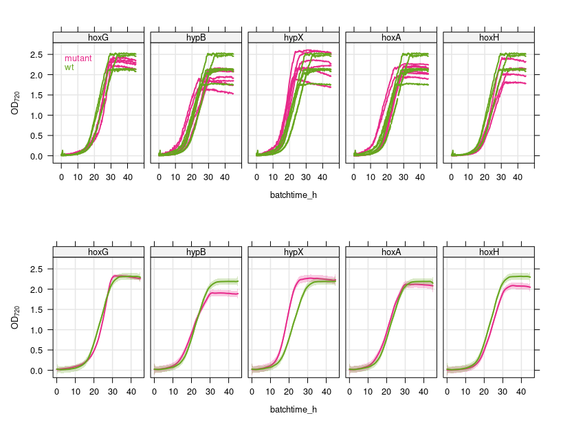

```r
print(plot_od_hox_mean, split = c(1, 2, 1, 2))
dev.off()
```

- maximum growth rate and biomass yield

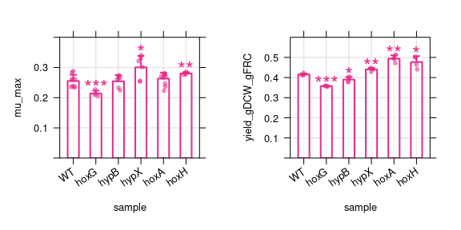

```r
df_mu_hox <- bind_rows(.id = "experiment",
  df_mu_20211206,
  df_mu_20211208 %>% filter(batchtime_h > 5),
  df_mu_20211214,
  df_mu_20220114,
  df_mu_20220404) %>%
  group_by(sample, experiment, channel_id) %>%
  summarize(mu_max = max(value), .groups = "drop") %>%
  mutate(sample = factor(sample, c("WT", "hoxG", "hypB", "hypX", "hoxA", "hoxH")))

df_dcw_hox <- bind_rows(
  df_DCW_20211208 %>% filter(sample != "hoxA"),
  df_DCW_20211214 %>% filter(sample != "hoxA"),
  df_DCW_20220114,
  df_DCW_20220404 %>% filter(sample == "hoxG")) %>%
  mutate(sample = factor(sample, c("WT", "hoxG", "hypB", "hypX", "hoxA", "hoxH")))

plot_barchart(df_mu_hox, "sample", "mu_max",
  ylim = c(0, 0.4), offset = 0.07, xrot = 35) %>%
  print(position = c(0,0,0.5,1), more = TRUE)

plot_barchart(df_dcw_hox, "sample", "yield_gDCW_gFRC",
  ylim = c(0, 0.6), offset = 0.1, xrot = 35) %>%
  print(position = c(0.5,0,1,1), more = TRUE)
```

```r
write_csv(df_mu_hox, "../../R-notebook-ralstonia-energy/data/growth_assays/df_mu_hox.csv")
write_csv(df_dcw_hox, "../../R-notebook-ralstonia-energy/data/growth_assays/df_dcw_hox.csv")
```

# 2022-04-11

## Cultivation of 3 mutants + WT in chemostats

- Purpose: to obtain (1) steady state yield and (2) optimal growth rate in continuous conditions
- more reliable and reproducible results

Preparations:

Calcultation of starting inocula:

```r
tibble(
    strain = c("WT", "hoxA", "hoxH", "hypX"),
    OD600_diluted = c(0.628, 0.473, 0.527, 0.480)
  ) %>%
  mutate(
    OD600 = OD600_diluted*4,
    V_for_OD_0.1 = 0.1/OD600,
    V_for_60_mL = V_for_OD_0.1*65
  )
```

| strain | OD600_diluted | OD600 | V_for_OD_0.1 | V_for_60_mL |
| --- | --- | --- | --- | --- |
| WT | 0.628 | 2.512 | 0.03980892 | 2.587580 |
| hoxA | 0.473 | 1.892 | 0.05285412 | 3.435518 |
| hoxH | 0.527 | 2.108 | 0.04743833 | 3.083491 |
| hypX | 0.480 | 1.920 | 0.05208333 | 3.385417 |

# 2022-04-13

## Cultivation of 3 mutants + WT in chemostats

Sampling of first time point, roughly 48 h of growth in batch, then chemostat mode.

- growth rate until now 0.1/h, chemostat
- sampled tube 5-8 (replicate 2)
- first 4 tubes (1st replicate of each strain) grew poorly due to error in medium composition
- replaced medium bottle after around 24 h growth with fresh medium
- all strains are growing but not all have reached equilibrium
- continue cultivation and sample all biol. replicates multiple times

## Cultivation of C. necator Tn library with nitrate respiration

Planning:

- nitrate respiration in chemostat worked poorly, due to constant resupply of NO3
- nitrate respiration in batch should be better, requiring cells to use all NO3 reduction steps (NO3, NO2, NO, respiration)
- need to plan the amount of NO3 carefully, so that it is limited:

Experiments:

- started preculture of a 0.5 ml TnLib aliquot in 10 mL LB medium
- transfer to MM + fructose after 24h, grow 24 more hours

# 2022-04-14

## Cultivation of 3 mutants + WT in chemostats

- sampled 2nd time point after all strains stabilized, t = 16:30

## Cultivation of C. necator Tn library with nitrate respiration

- inoculated 2nd preculture, 15 mL MM + 2 g/L Frc + 5 mL LB preculture from previous day
- autoclaved 8 gas-tight 100 mL bottles

# 2022-04-15

## Cultivation of 3 mutants + WT in chemostats

- sampled 3rd time point t = 11:00
- set growth rate to µ = 0.2/h

## Cultivation of C. necator Tn library with nitrate respiration

- for nitrate respiration, need to replace O2 athmosphere with NaNO3 in medium
- for a conc of 2 g/L Frc, we can use 0.5 g/L NaNO3 (as in [Kohlnann et al., 2014](https://pubs.acs.org/doi/10.1021/pr500491r))
- from GEM, we know that 1 mmol Fru (0.18 g) per g biomass requires 3 mmol O2 (0.05 g). 3 mmol NaNO3 correspond to 0.26 g NaNO3, roughly a mass ratio of 1.44 g NaNO3/ g Fru.
- considering that NO3 has 3 instead of 2 oxygens atoms, we probably need less for same oxidation power
- using 2x what Kohlmann et al. used, 1 g/L NaNO3 for 2 g/L Fru, should still be enough to make cells depend on full denitrification cycle (i.e. be respiration limited)
- filled 4 gas cultivation bottles with 30 mL MM + 2 g/L Frc + 1 g/L NH4 + 1 g/L NaNO3
- inoculated to OD600 = 0.1, can theoretically grow to approx. OD600 = 2 (4+ generations, 0.1->0.2->0.4->0.8->1.6)
- pressurized to 1 bar (over pressure) with N2
- shake at 30*C, 150 RPM

# 2022-04-16

## Cultivation of 3 mutants + WT in chemostats

- sampled 4th time point at around t = 11:00
- stopped reactor after it consumed most medium

**Summary of chemostat cultivation**

- OD over time

```r
df_OD_20220411 <- read_csv(paste0(dir_exp, "20220411_MC4_Re_mutants_chemostat/20220411_MC4_measurements.csv"),
  show_col_types = FALSE, col_select = -1) %>% filter(od_led == 720) %>%
  mutate(sample = case_when(channel_id %in% c(1,5) ~ "WT", channel_id %in% c(2,6) ~ "hoxA",
    channel_id %in% c(3,7) ~ "hoxH", channel_id %in% c(4,8) ~ "hypX")) %>%
  group_by(sample, batchtime_h) %>% mutate(replicate = 1:n())
```

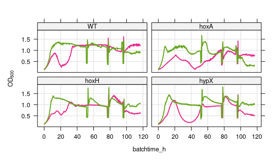

```r
plot_OD(df_OD_20220411, groups = "replicate", layout = c(2,2))
```

- DCW measurements for growth rate = 0.1 and 0.2
- no significant trend visible, and variation was quite high as already seen in chemostat OD measurements
- it remains open if mutants have different growth rate than WT (in cont. culture)

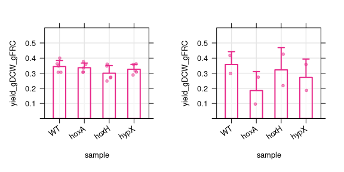

```r
df_DCW_20220411 <- read_csv(paste0(dir_exp, "20220411_MC4_Re_mutants_chemostat/20220411_gDCW.csv"), col_types = cols()) %>%
  mutate(
    DCW_mg = total_weight_mg - tube_weight_mg,
    yield_gDCW_gFRC = DCW_mg/(1000 * 1.0 * 0.05)
  )

df_DCW_20220411 %>% filter(growth_rate == 0.1) %>%
  plot_barchart("sample", "yield_gDCW_gFRC", ylim = c(0, 0.6), offset = 0.1, xrot = 35) %>%
  print(split = c(1,1,2,1), more = TRUE)
df_DCW_20220411 %>% filter(growth_rate == 0.2) %>%
  plot_barchart("sample", "yield_gDCW_gFRC", ylim = c(0, 0.6), offset = 0.1, xrot = 35) %>%
  print(split = c(2,1,2,1))
```

# 2022-04-18

## Cultivation of C. necator Tn library with nitrate respiration

- samples reached final OD600 ~ 1.2
- sampled 1st time point (t ~ 3-4 generations)
- diluted samples back to 30 mL of OD600 = 0.1
- refilled with 1 bar N2 using gas dispenser

# 2022-04-19

## Cultivation of C. necator Tn library with nitrate respiration

- samples reached final OD600 ~ 1.2
- sampled 2nd time point (t ~ 7-8 generations)
- diluted samples back to 30 mL of OD600 = 0.1
- refilled with 1 bar N2 using gas dispenser

# 2022-04-20

## Cultivation of C. necator Tn library with nitrate respiration

- samples reached final OD600 ~ 1.2
- sampled 3rd and final time point (t ~ 10-12 generations)
- results of gas bottle cultivation

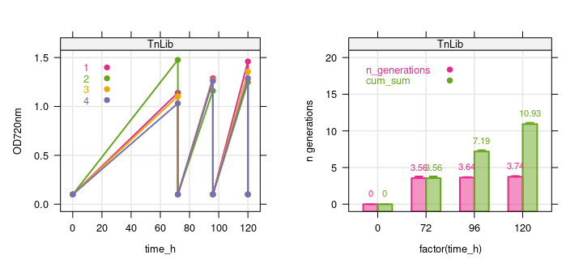

```r
# estimate N generations
df_OD_20220415 <- read_csv(paste0(dir_exp, "20220415_NO3_cultivation_Re_TnLib/20220415_NO3_Cnecator.csv")) %>%
  pivot_longer(cols = matches("^OD_(current|target)"), names_to = "OD_type", values_to = "OD") %>%
  group_by(sample, time_h, replicate) %>%
  mutate(n_generations = case_when(
    time_h != 0 ~ log2(OD/0.1), TRUE ~ 0)) %>%
  group_by(sample, replicate) %>%
  mutate(cum_sum = cumsum(n_generations))
# Plotting
xyplot(OD ~ time_h | sample,
  filter(df_OD_20220415, !(time_h == 0 & OD > 0.1)),
  groups = replicate, lwd = 2, ylim = c(-0.075, 1.575),
  par.settings = custom.colorblind(),
  ylab = "OD720nm", type = c("p", "l"),
  scales = list(alternating = FALSE),
  as.table = TRUE, between = list(x = 0.5, y = 0.5),
  panel=function(x, y, ...) {
    panel.grid(h = -1, v = -1, col = grey(0.9))
    panel.xyplot(x, y, ...)
    panel.key(...)
  }
) %>% print(split = c(1,1,2,1), more = TRUE)

xyplot(n_generations + cum_sum ~ factor(time_h) | sample,
  filter(df_OD_20220415, OD != 0.1), par.settings = custom.colorblind(),
  scales = list(alternating = FALSE), ylim = c(-1, 21),
  between = list(x = 0.5, y = 0.5), beside = TRUE,
  border = "white", ylab = "n generations", ewidth = 0.15,
  panel = function(x, y, ...) {
    panel.grid(h = -1, v = -1, col = grey(0.9))
    panel.barplot(x, y, fill_alpha = 0.5, lwd = 2, ...)
    panel.annotate(x, y, digits = 2, offset = 1.5, cex = 0.7, ...)
    panel.key(...)
  }
) %>% print(split = c(2,1,2,1))
```

## Tn library with nitrate respiration, NGS sample preparation

- gDNA extraction using Thermo Gene Jet kit
- starting material: 16 samples from 4 time points x 4 replicates
- average cell mass is 3 mL of OD600 = 1.2 (3.6 OD units)
- protocol according to manufacturer
- eluted gDNA in 2 x 50 µL elution buffer

```r
df_NGS_20220420 <- read_csv(paste0(dir_exp, "20220420_NO3_TnLib_NGS_prep/sample_concentration.csv"), col_types = cols())
print(df_NGS_20220420)
```

| sample | replicate | conc_ng_uL | A260/A280 | A260/A230 | primer_F | primer_R |
| --- | --- | --- | --- | --- | --- | --- |
| NO3_0gen | 1 | 165.0 | 1.913 | 2.011 | primer_1 | phasing_pool_2 |
| NO3_0gen | 2 | 109.0 | 1.879 | 1.942 | primer_2 | phasing_pool_2 |
| NO3_0gen | 3 | 133.0 | 1.909 | 2.058 | primer_3 | phasing_pool_2 |
| NO3_0gen | 4 | 253.6 | 1.908 | 2.252 | primer_4 | phasing_pool_2 |
| NO3_4gen | 1 | 99.9 | 1.896 | 2.117 | primer_5 | phasing_pool_2 |
| NO3_4gen | 2 | 69.0 | 1.881 | 1.869 | primer_6 | phasing_pool_2 |
| NO3_4gen | 3 | 120.8 | 1.897 | 2.107 | primer_7 | phasing_pool_2 |
| NO3_4gen | 4 | 71.9 | 1.861 | 2.129 | primer_8 | phasing_pool_2 |
| NO3_8gen | 1 | 103.8 | 1.867 | 2.002 | primer_9 | phasing_pool_2 |
| NO3_8gen | 2 | 118.8 | 1.894 | 2.119 | primer_10 | phasing_pool_2 |

[output cut: 6 more lines]

- PCR to amplify barcodes
- using NEB Q5 master mix
- recipe, see table
- program: according to manufacturer (“BARSEQ98”)

| component | volume 1x | volume 18x |
| --- | --- | --- |
| Q5 MM 2x | 10 | 180 |
| H2O | 4 | 72 |
| F-primer 10 uM | 2 | - |
| R-primer 10 uM | 2 | 36 |
| gDNA 200-400 ng | 2 | - |
| Total | 20 | 16/well |

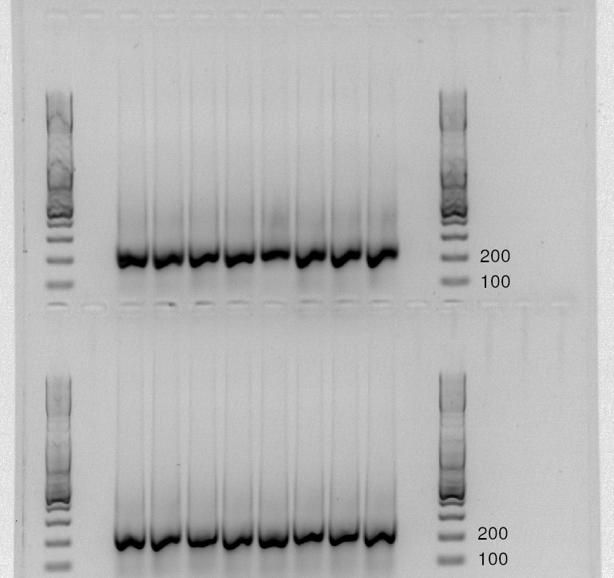

Gel with 16 PCR products and expected size 180 = bp

**Summary:**

- gDNA extraction and PCR successfull
- expected PCR product size = 180 bp is OK
- Nick will measure DNA concentration with qBit and do library prep